# Predictors of Scene Timing Performance Following Concussion

Multiple Regression Analysis — PSYC 6132

2026-04-01

# a) Research Problem & Theoretical Rationale

### Concussion and persistent post-concussion symptoms

Concussion is a type of mild traumatic brain injury (mTBI)

- Symptoms include headaches, nausea, impaired balance, double vision, sensory sensitivities, impaired memory and concentration, irritability
- Expected recovery period is 7-10 days

Persistent post-concussion symptoms

- Experienced by 10-20% of individuals following concussion
- Can last for weeks, months, or years
- Working-aged adults, especially females, are underrepresented in PPCS research

### Cognitive-motor integration

Cognitive-motor integration (CMI)

- Unconscious process of integrating visual information and motor planning to execute movement
- Studies have found that CMI performance is impaired following concussion
- Sex differences in CMI performance in working-aged adults with PPCS are not yet well understood

### Aim and hypotheses

Aim: Examine the relationships between CMI performance, symptom burden, and sex in a sample of 41 working-aged adults with PPCS (24 female, 29-64 years, mean 47.2 +/- 9.2)

Hypotheses:

1. Post-concussion symptom severity will predict worse performance (higher timing composite scores) on a CMI task.
2. There will be significant interactions between sex and symptom severity on CMI performance.

# b) Variables

### CMI Task

Sliding index finger along a touchpad to move a cursor from a presented central target to a peripheral target (up, down, left, or right)

- Plane change: the finger movement is on a horizontally placed touchpad, whereas the task and cursor movement are presented on the vertical plane of the laptop screen
- Feedback reversal: the cursor moves in the opposite direction as the finger
- 20 trials

Timing composite score: an addition of three z-standardized timing measures

- Reaction time (ms)
- Full movement time (ms)
- Peak velocity (mm/ms)

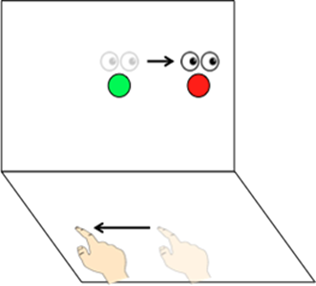

### Variable Details

**Criterion variable**

| Variable | Description | Scale |
| --- | --- | --- |
| 8TimingComp | Scene completion time composite | Continuous (z-scored composite; higher = slower performance) |

**Predictors**

| Variable | Description | Scale | Model |
| --- | --- | --- | --- |
| AGE | Participant age | Continuous (years) | Both models |
| Sex_Recode_F1M0 | Biological sex | Binary (0 = Male, 1 = Female) | Both models |
| DHI | Dizziness Handicap Inventory | Continuous (0–100; higher = greater dizziness handicap) | Both models |
| RPQ_3 | Rivermead Post-Concussion Symptoms — 3 early symptoms | Continuous (0–12; higher = more severe) | Both models |
| RPQ_13 | Rivermead Post-Concussion Symptoms — 13 later symptoms | Continuous (0–52; higher = more severe) | Both models |
| DaysSinceLastConcussion | Days elapsed since most recent concussion (control variable) | Continuous (days) | Both models (control) |

Model 2 additionally includes the interaction terms **Sex × DHI**, **Sex × RPQ_3**, and **Sex × RPQ_13**, testing whether the effect of each symptom scale on timing performance differs between males and females.

# c) Regression Equations

**Model 1 — Main Effects (mean-centred continuous predictors)**

$$\hat{Y} = b_0 + b_1(\text{AGE}_c) +
b_2(\text{Sex}) + b_3(\text{DHI}_c) + b_4(\text{RPQ\_3}_c) +
b_5(\text{RPQ\_13}_c) + b_6(\text{Days}_c) + \varepsilon$$

Where the subscript $_c$ denotes mean-centred predictors. Centring does not change model fit, *F*-statistics, or the standardised coefficients; it shifts the intercept to the predicted value at the mean of all continuous predictors and eliminates structural collinearity with interaction terms in Model 2.

**DAG: Model 1 Variable Relationships**

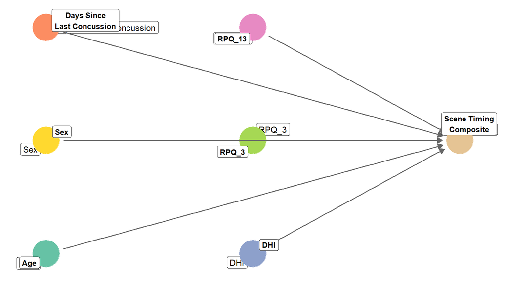

Model 1 Coefficients (mean-centred continuous predictors)

|  | Predictor | b | SE | t | p |
| --- | --- | --- | --- | --- | --- |
| (Intercept) | Intercept | -0.408 | 0.354 | -1.151 | 0.258 |
| AGE_c | AGE (centred) | 0.074 | 0.023 | 3.287 | 0.002 |
| Sex_Recode_F1M0 | Sex (F=1, M=0) | 0.697 | 0.485 | 1.436 | 0.160 |
| DHI_c | DHI (centred) | 0.024 | 0.012 | 1.926 | 0.063 |
| RPQ_3_c | RPQ_3 (centred) | 0.123 | 0.125 | 0.983 | 0.332 |
| RPQ_13_c | RPQ_13 (centred) | -0.034 | 0.026 | -1.305 | 0.201 |
| Days_c | Days Since Concussion (centred) | 0.000 | 0.000 | -1.699 | 0.098 |

**Model 2 — Main Effects + Sex × Symptom Interactions (mean-centred continuous predictors)**

$$\hat{Y} = b_0 + b_1(\text{AGE}_c) +
b_2(\text{Sex}) + b_3(\text{DHI}_c) + b_4(\text{RPQ\_3}_c) +
b_5(\text{RPQ\_13}_c) + b_6(\text{Days}_c) + b_7(\text{Sex} \times
\text{DHI}_c) + b_8(\text{Sex} \times \text{RPQ\_3}_c) + b_9(\text{Sex}
\times \text{RPQ\_13}_c) + \varepsilon$$

**DAG: Model 2 Variable Relationships**

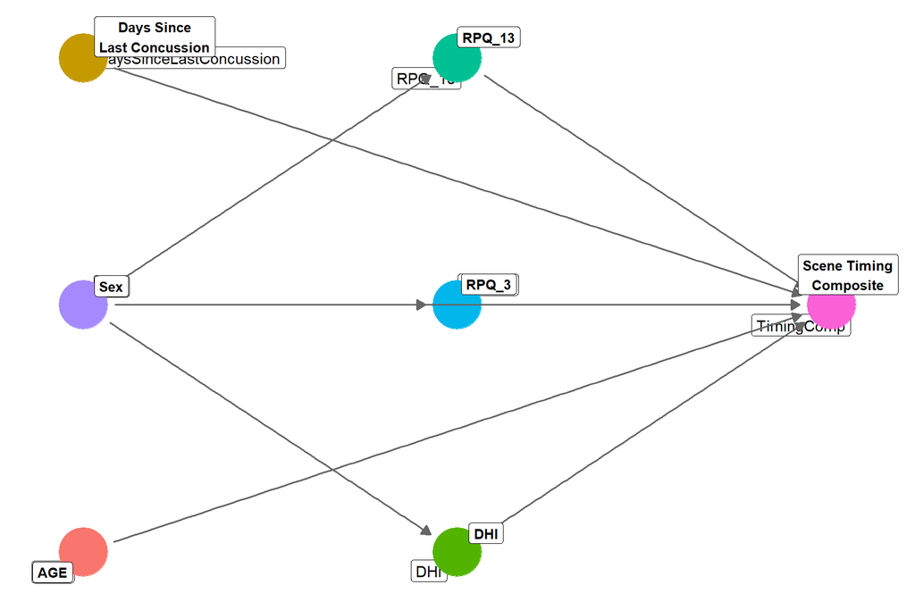

Model 2 Coefficients (mean-centred continuous predictors)

|  | Predictor | b | SE | t | p |
| --- | --- | --- | --- | --- | --- |
| **Main Effects** |  |  |  |  |  |
| (Intercept) | Intercept | -0.409 | 0.396 | -1.034 | 0.309 |
| AGE_c | AGE (centred) | 0.071 | 0.023 | 3.088 | 0.004 |
| Sex_Recode_F1M0 | Sex (F=1, M=0) | 0.712 | 0.503 | 1.415 | 0.167 |
| DHI_c | DHI (centred) | 0.035 | 0.017 | 2.040 | 0.050 |
| RPQ_3_c | RPQ_3 (centred) | -0.112 | 0.270 | -0.414 | 0.682 |
| RPQ_13_c | RPQ_13 (centred) | 0.022 | 0.056 | 0.399 | 0.693 |
| Days_c | Days Since Concussion (centred) | 0.000 | 0.000 | -1.538 | 0.134 |
| **Interaction Terms (Sex × Symptom Scale)** |  |  |  |  |  |
| Sex_Recode_F1M0:DHI_c | Sex × DHI (centred) | -0.020 | 0.025 | -0.794 | 0.433 |
| Sex_Recode_F1M0:RPQ_3_c | Sex × RPQ_3 (centred) | 0.291 | 0.312 | 0.931 | 0.359 |
| Sex_Recode_F1M0:RPQ_13_c | Sex × RPQ_13 (centred) | -0.063 | 0.064 | -0.975 | 0.337 |

# d) Critical Test

**Model 1:** The critical elements are the **symptom severity predictors** — DHI, RPQ_3, and RPQ_13. We expect one or more of $b_3$, $b_4$, $b_5$ to be positive and statistically significant (*p* < .05), indicating that higher symptom burden predicts worse (slower) scene timing performance, after controlling for age, sex, and recovery duration.

**Model 2:** The additional critical test concerns the **Sex × symptom interaction terms** ($b_7$, $b_8$, $b_9$). A significant interaction would indicate that the relationship between a given symptom scale and timing performance differs depending on sex — consistent with the hypothesis that females and males translate equivalent symptom levels into differential functional impairment. This is evaluated both via the individual interaction *t*-tests and via a nested model comparison (likelihood-ratio / *F*-test) between Model 1 and Model 2, where a significant $\Delta \chi^2$ or $\Delta F$ would indicate that adding the interaction terms meaningfully improves model fit.

The inclusion of **DaysSinceLastConcussion** as a covariate is important in both models: symptom scores naturally decrease over time, so controlling for recovery duration isolates the *concurrent* symptom-performance relationship rather than conflating it with recovery trajectory.

# e) Assumption Checks

Assumptions are checked separately for each model. Because Model 2 adds interaction terms, it is subject to the same six standard regression assumptions; the key additional consideration is that interactions between a binary variable (Sex) and continuous predictors can elevate multicollinearity among the expanded predictor set, which is specifically examined in the multicollinearity tab.

## Model 1 — Main Effects

### 1. Linearity

**Residuals vs. Fitted (composite)**

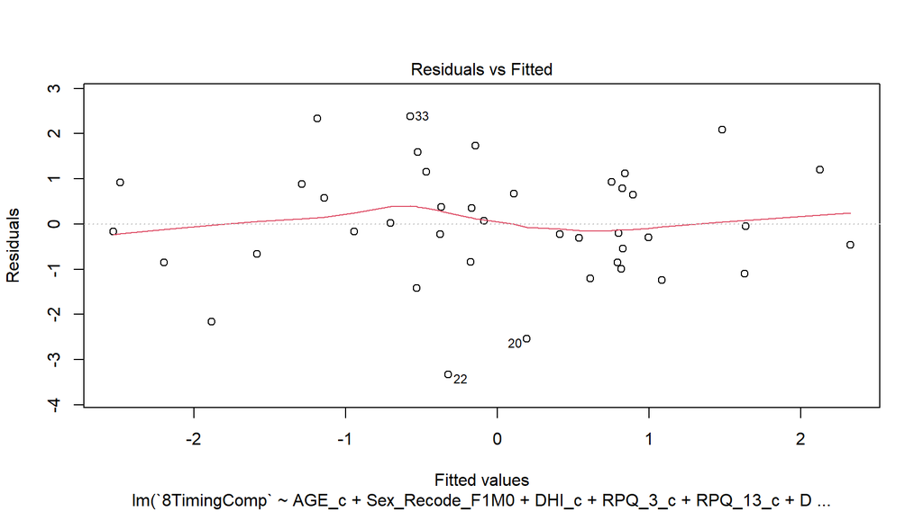

Look for random scatter around the horizontal zero line. A systematic curve or U-shape indicates non-linearity in the model’s linear combination of predictors.

**Added-Variable Plots (per predictor)**

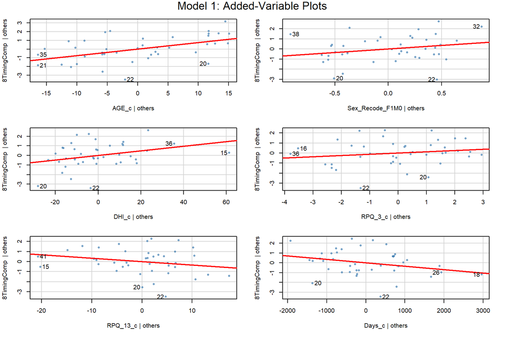

Each panel shows the unique linear relationship between one predictor and the outcome after partialling out all others. A roughly linear trend in each panel is expected; a curve flags a problem for that specific predictor.

> **Verdict: No violation.** The Residuals vs. Fitted plot shows random scatter around zero with no systematic curve. Added-variable plots show approximately linear trends for all six predictors. The assumption of linearity is satisfied.

### 2. Normality

**Q-Q Plot of Residuals**

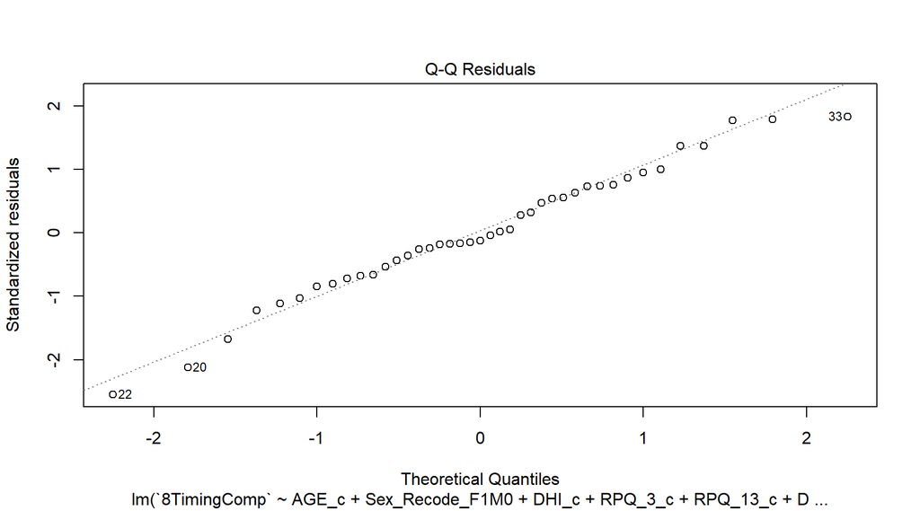

Points should follow the diagonal reference line closely. Systematic S-curves or pronounced heavy tails indicate departures from normality, which can inflate Type I error rates and distort confidence intervals in small samples.

> **Verdict: No violation.** The Q-Q plot shows points tracking closely along the diagonal with only minor deviations at the tails. A Shapiro-Wilk test on the residuals confirms this (*W* = 0.981, *p* = .731), providing no evidence of non-normality.

### 3. Homoscedasticity

**Scale-Location Plot**

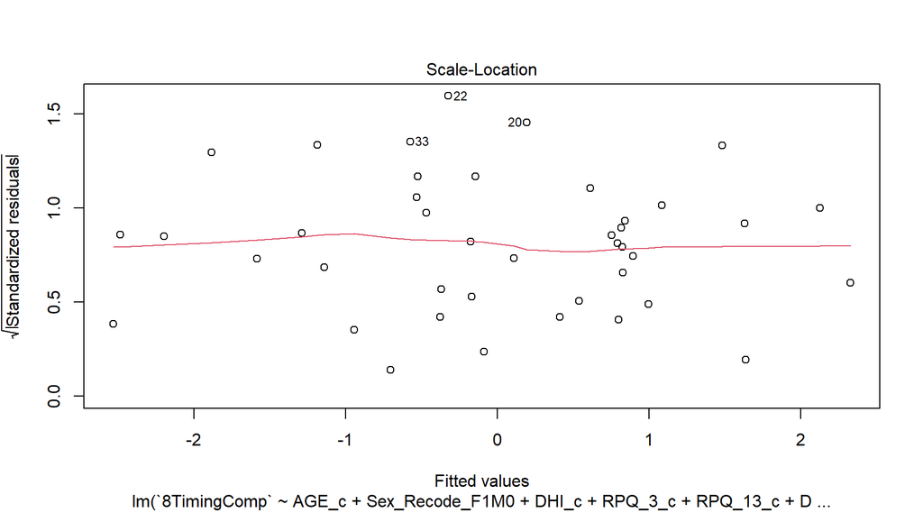

The LOESS line should be roughly horizontal with consistent spread across the range of fitted values. A rising trend or funnel shape indicates heteroscedasticity, which produces biased standard errors and distorts *p*-values and confidence intervals.

> **Verdict: No violation.** The Scale-Location plot shows a roughly flat LOESS line with no systematic funnel pattern. A formal score test for non-constant variance was non-significant (*p* = .518), indicating homoscedasticity is satisfied.

### 4. Independence

**Residuals vs. Observation Order**

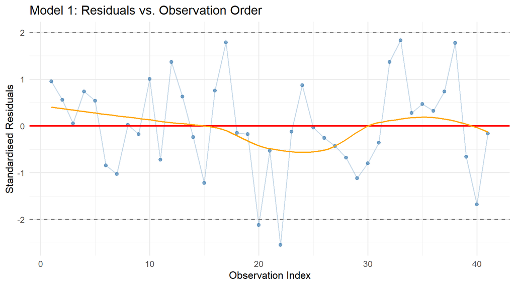

No systematic trend, wave, or drift across the observation sequence is expected. A pattern suggests autocorrelation or a data-collection order effect.

> **Verdict: No violation.** The index plot shows no strong wave-like pattern, and the study design didn’t create any participant clusters that could suggest otherwise.

### 5. Multicollinearity

**Predictor Correlation Heat Map**

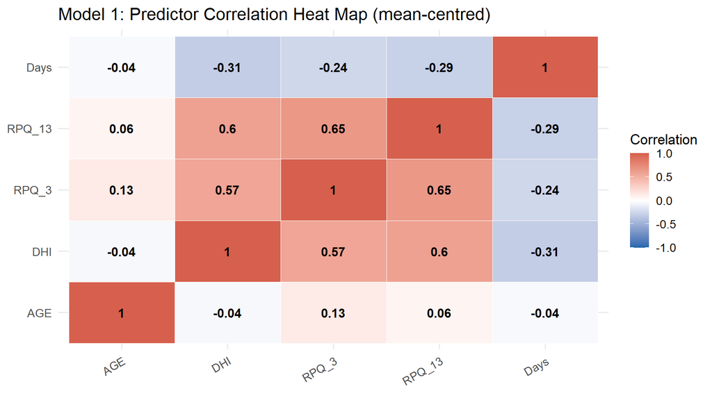

**VIF Bar Chart**

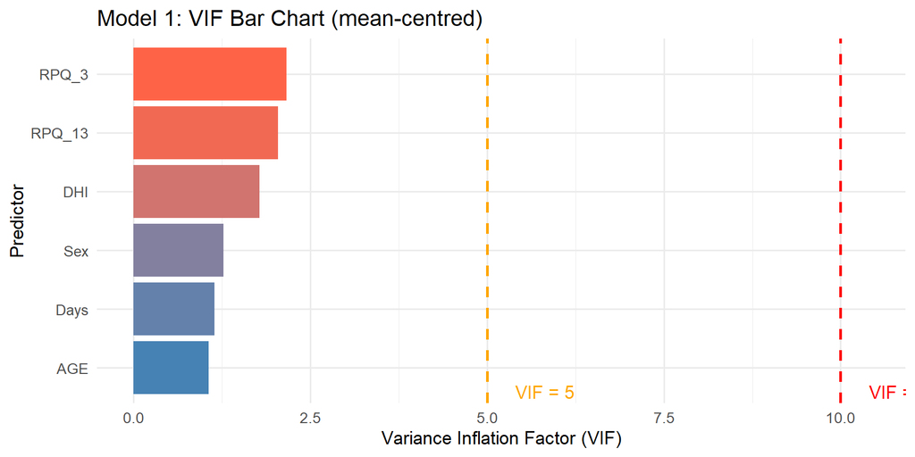

Correlations approaching ±0.80 between predictors are concerning. RPQ_3 and RPQ_13 are likely to be moderately correlated given they are subscales of the same instrument. VIF > 5 indicates moderate concern; VIF > 10 indicates serious multicollinearity.

> **Verdict: No violation.** The correlation heat map shows the strongest inter-predictor correlation between RPQ_3 and RPQ_13 (*r* = .65) and between DHI and RPQ_13 (*r* = .60), both expected given they measure related symptom domains. No correlation exceeds ±0.80. All VIF values are well below 5 (AGE = 1.06, Sex = 1.27, DHI = 1.78, RPQ_3 = 2.16, RPQ_13 = 2.04, Days = 1.15), indicating no problematic multicollinearity.

### 6. Fixed Predictors

**Predictor Distributions**

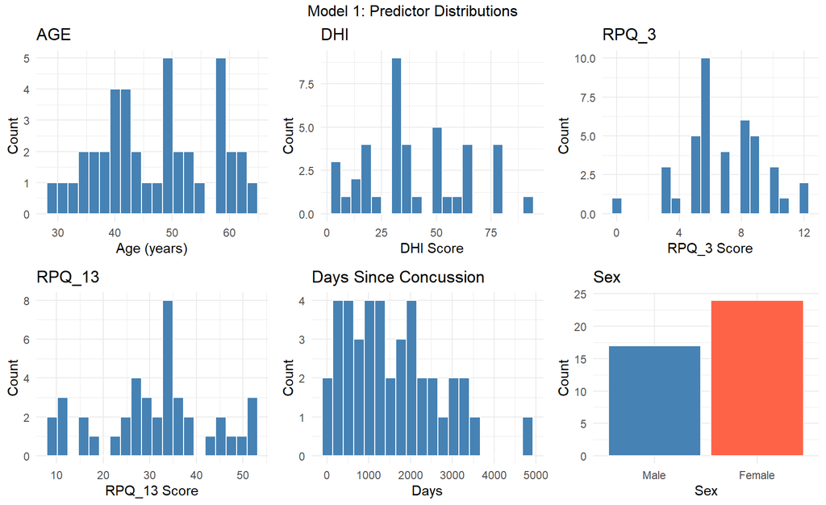

Distributions should be plausible and free of implausible extreme values. Extreme outliers in any continuous predictor can exert undue leverage on the regression solution.

## Model 2 — Sex × Symptom Interactions

### 1. Linearity

**Residuals vs. Fitted (composite)**

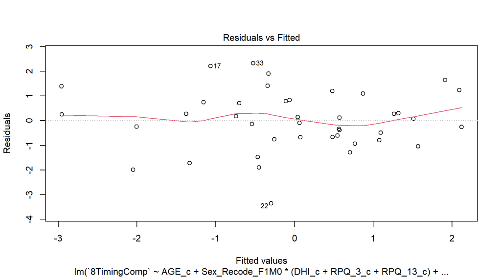

**Added-Variable Plots (per predictor)**

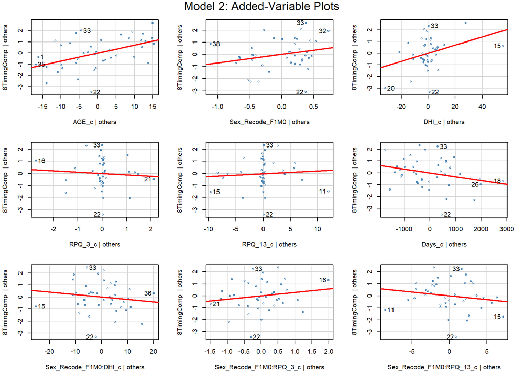

With interaction terms included, the added-variable plots cover both the constituent main effects and each Sex × symptom cross-product. The interaction terms themselves are products of continuous and binary variables, so mild non-linearity in those panels is less interpretively concerning than in the main-effect panels.

> **Verdict: No violation.** The Residuals vs. Fitted plot shows random scatter around zero with no systematic curve. The added-variable plots show approximately linear trends for all main-effect predictors. The interaction term panels are also consistent with linearity given the binary nature of the Sex moderator.

### 2. Normality

**Q-Q Plot of Residuals**

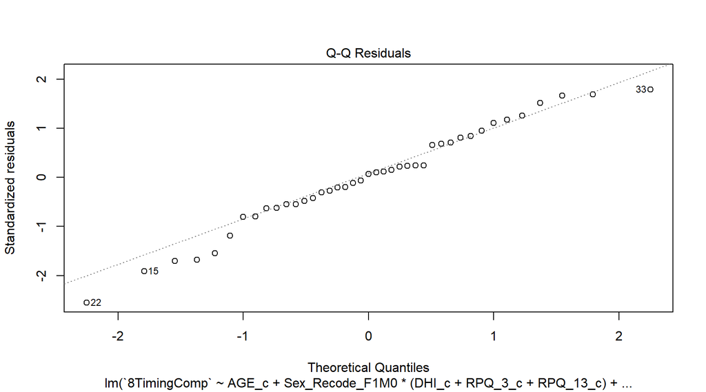

> **Verdict: No violation.** The Q-Q plot shows points tracking closely along the diagonal. A Shapiro-Wilk test confirms normality of residuals (*W* = 0.985, *p* = .870), with slightly better fit than Model 1 owing to the reduced residual variance after adding interaction terms.

### 3. Homoscedasticity

**Scale-Location Plot**

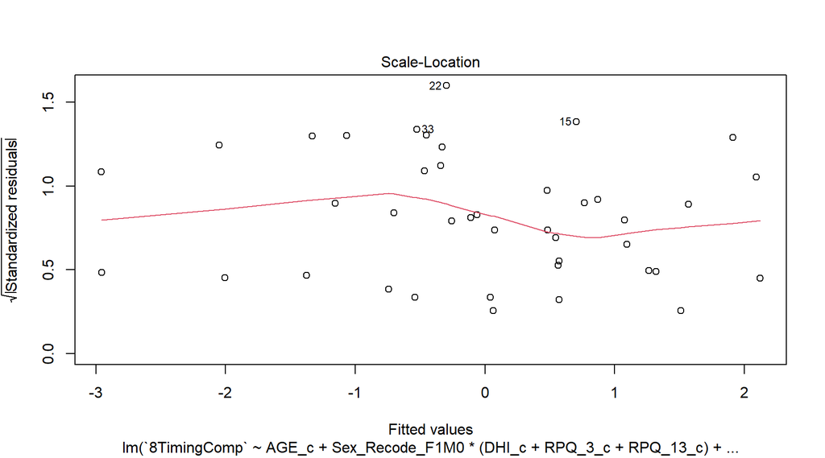

Heteroscedasticity is worth particular attention in Model 2: if the error variance differs across the two sex groups, this can manifest as a pattern in the Scale-Location plot and would distort inference for the interaction terms specifically.

> **Verdict: No violation.** The Scale-Location plot shows no systematic funnel or trend. A formal score test for non-constant variance is non-significant (*p* = .238), indicating that error variance is consistent across fitted values and does not differ systematically between male and female subgroups.

### 4. Independence

**Residuals vs. Observation Order**

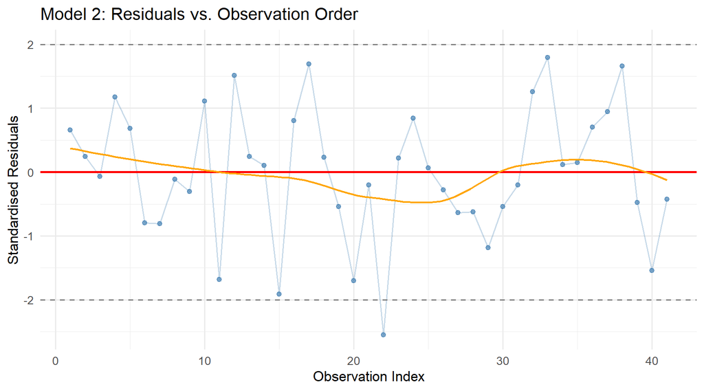

> **Verdict: No violation.** The index plot shows no strong wave-like pattern like in Model 1, and the study design didn’t create any participant clusters that could suggest otherwise.

### 5. Multicollinearity

**VIF Bar Chart — Model 2**

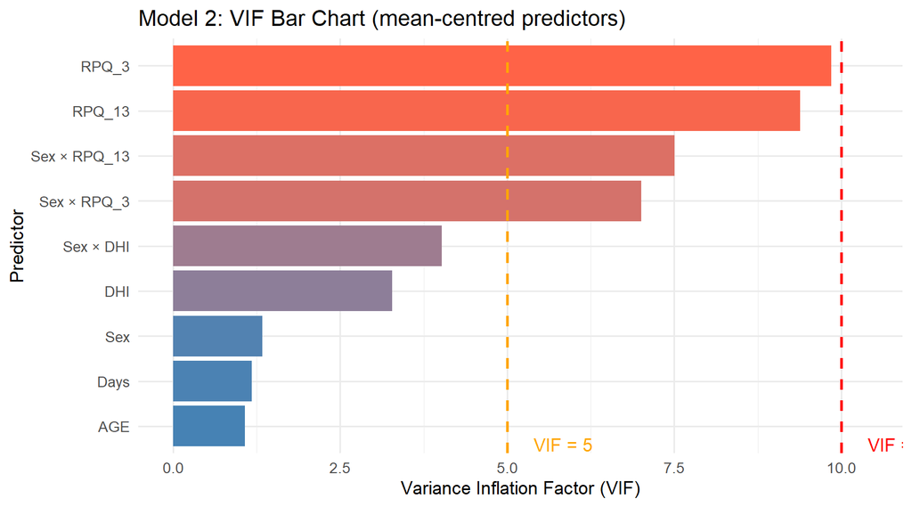

### 6. Fixed Predictors

The predictor distributions for Model 2 are identical to those shown for Model 1 — the same variables and the same observed values are used. Please refer to the **Model 1 → Fixed Predictors** tab for these plots. The interaction terms are computed from existing variables and do not require separate distributional checks.

# f) Conclusion & Interpretation

## Model Comparison

Model Comparison Summary

| Model | Predictors | Res. df | RSS | AIC |
| --- | --- | --- | --- | --- |
| Model 1: Main Effects | AGE, Sex, DHI, RPQ_3, RPQ_13, Days | 34 | 62.533 | 149.660 |
| Model 2: + Sex × Symptom Interactions | Above + Sex×DHI, Sex×RPQ_3, Sex×RPQ_13 | 31 | 58.381 | 152.843 |

The nested model comparison showed that adding the three Sex × symptom interaction terms did not significantly improve model fit: $\Delta RSS$ = 4.152, $\Delta df$ = 3, *p* = 0.531. The AIC was lower for Model 1 (AIC = 149.66) than for Model 2 (AIC = 152.843), indicating that the simpler main-effects model is preferred after penalising for complexity. **Model 1 is therefore the preferred model.**

## Model 1 Results

The main-effects model accounted for **R² = 0.475** of the variance in scene timing performance (adjusted R² = 0.383), *F*(6, 34) = 5.14, *p* = 0.001.

Model 1: Coefficient Table (significant predictors highlighted)

|  | Predictor | Beta | SE | t | p |
| --- | --- | --- | --- | --- | --- |
| (Intercept) | Intercept | -0.408 | 0.354 | -1.151 | 0.258 |
| AGE_c | AGE | 0.074 | 0.023 | 3.287 | 0.002 |
| Sex_Recode_F1M0 | Sex (F=1, M=0) | 0.697 | 0.485 | 1.436 | 0.160 |
| DHI_c | DHI | 0.024 | 0.012 | 1.926 | 0.063 |
| RPQ_3_c | RPQ_3 | 0.123 | 0.125 | 0.983 | 0.332 |
| RPQ_13_c | RPQ_13 | -0.034 | 0.026 | -1.305 | 0.201 |
| Days_c | Days Since Last Concussion | 0.000 | 0.000 | -1.699 | 0.098 |

A positive *b* coefficient indicates that higher scores on that variable are associated with slower (worse) scene timing performance, holding all other predictors constant. Rows highlighted in blue are statistically significant at *p* < .05.

## Model 2 Results

The interaction model accounted for **R² = 0.51** of the variance in scene timing performance (adjusted R² = 0.368), *F*(9, 31) = 3.59, *p* = 0.004.

Model 2: Coefficient Table (significant predictors highlighted)

|  | Predictor | Beta | SE | t | p |
| --- | --- | --- | --- | --- | --- |
| **Main Effects** |  |  |  |  |  |
| (Intercept) | Intercept | -0.409 | 0.396 | -1.034 | 0.309 |
| AGE_c | AGE | 0.071 | 0.023 | 3.088 | 0.004 |
| Sex_Recode_F1M0 | Sex (F=1, M=0) | 0.712 | 0.503 | 1.415 | 0.167 |
| DHI_c | DHI | 0.035 | 0.017 | 2.040 | 0.050 |
| RPQ_3_c | RPQ_3 | -0.112 | 0.270 | -0.414 | 0.682 |
| RPQ_13_c | RPQ_13 | 0.022 | 0.056 | 0.399 | 0.693 |
| Days_c | Days Since Last Concussion | 0.000 | 0.000 | -1.538 | 0.134 |
| **Interaction Terms** |  |  |  |  |  |
| Sex_Recode_F1M0:DHI_c | Sex × DHI | -0.020 | 0.025 | -0.794 | 0.433 |
| Sex_Recode_F1M0:RPQ_3_c | Sex × RPQ_3 | 0.291 | 0.312 | 0.931 | 0.359 |
| Sex_Recode_F1M0:RPQ_13_c | Sex × RPQ_13 | -0.063 | 0.064 | -0.975 | 0.337 |

None of the three Sex × symptom interaction terms reached statistical significance, consistent with the model comparison result. Note that in Model 2, the main effect of DHI represents the effect of DHI *specifically for males* (Sex = 0), not the average effect across both sexes as in Model 1. The same applies to Sex × RPQ_3 and Sex × RPQ_13 terms.